# Personal Activity Prediction

A. Amin

Saturday, June 06, 2015

## Executive Summary

Using devices such as Jawbone Up, Nike FuelBand, and Fitbit it is now possible to collect a large amount of data about personal activity relatively inexpensively. These type of devices are part of the quantified self movement - a group of enthusiasts who take measurements about themselves regularly to improve their health, to find patterns in their behavior, or because they are tech geeks. One thing that people regularly do is quantify how much of a particular activity they do, but they rarely quantify how well they do it.

In this project, the goal will be to use data from accelerometers on the belt, forearm, arm, and dumbell of 6 participants. They were asked to perform barbell lifts correctly and incorrectly in 5 different ways. More information is available from the website here: http://groupware.les.inf.puc-rio.br/har (see the section on the Weight Lifting Exercise Dataset).

The investigation found that Random forest delivers the best prediction with highest accuracy.

## Analysis

#### Step 1. Load library

```r
library(AppliedPredictiveModeling)
library(caret)
library(ggplot2)
library(randomForest)
```

#### Step 2: Data preparation

Load csv and identify NA values

```r
data = read.csv("pml-training.csv", na.strings=c("NA","","#DIV/0!"), sep=",")
val_data = read.csv("pml-testing.csv", na.strings=c("NA","","#DIV/0!"), sep=",")
```

Remove the first 7 columns from the training, testing, and validating dataset because usernames and timestamps should not be predictors of the activities.

```r
data = data[,-seq(1:7)]
val_data = val_data[,-seq(1:7)]

na_values <- sapply(data, function (x) any(is.na(x) | x == ""))
usable_columns_names <- names(na_values)[!na_values]
```

After dataset clean up, it is found there are 52 predictors columns and the result (“classe” column).

```r
print(usable_columns_names)
```

```
##  [1] "roll_belt"            "pitch_belt"           "yaw_belt"
##  [4] "total_accel_belt"     "gyros_belt_x"         "gyros_belt_y"
##  [7] "gyros_belt_z"         "accel_belt_x"         "accel_belt_y"
## [10] "accel_belt_z"         "magnet_belt_x"        "magnet_belt_y"
## [13] "magnet_belt_z"        "roll_arm"             "pitch_arm"
## [16] "yaw_arm"              "total_accel_arm"      "gyros_arm_x"
## [19] "gyros_arm_y"          "gyros_arm_z"          "accel_arm_x"
## [22] "accel_arm_y"          "accel_arm_z"          "magnet_arm_x"
## [25] "magnet_arm_y"         "magnet_arm_z"         "roll_dumbbell"
## [28] "pitch_dumbbell"       "yaw_dumbbell"         "total_accel_dumbbell"
## [31] "gyros_dumbbell_x"     "gyros_dumbbell_y"     "gyros_dumbbell_z"
## [34] "accel_dumbbell_x"     "accel_dumbbell_y"     "accel_dumbbell_z"
## [37] "magnet_dumbbell_x"    "magnet_dumbbell_y"    "magnet_dumbbell_z"
## [40] "roll_forearm"         "pitch_forearm"        "yaw_forearm"
## [43] "total_accel_forearm"  "gyros_forearm_x"      "gyros_forearm_y"
## [46] "gyros_forearm_z"      "accel_forearm_x"      "accel_forearm_y"
## [49] "accel_forearm_z"      "magnet_forearm_x"     "magnet_forearm_y"
## [52] "magnet_forearm_z"     "classe"
```

#### Step 3: Determine the training, testing and validating dataset.

Finally, define the training dataset, testing dataset, and the validating dataset.

```r
data <- data[,usable_columns_names]
inTrain <- createDataPartition(y=data$classe, p=0.60, list=FALSE)
training <- data[inTrain,]
testing <- data[-inTrain,]

validating <- val_data[,subset(usable_columns_names, usable_columns_names!="classe")]

x <- rbind(dim(training),dim(testing),dim(validating))
rownames(x) <- c("training dataset","testing dataset","validating dataset")
colnames(x) <- c("#row","#column")
print(x)
```

```
##                     #row #column
## training dataset   11776      53
## testing dataset     7846      53
## validating dataset    20      52
```

#### Step 4: Quick evaluation of some predictors

You can view what is the density of each predictors to each other, the bigger the difference between predictors, the higher chance the prediction will be able to provide a correct prediction. Due to the high number of predictors, only a few first and last selected predictors as examples will be shown.

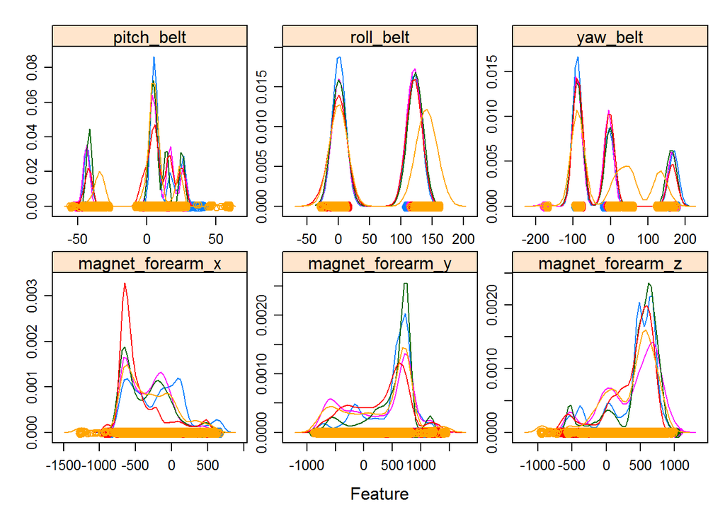

```r
featurePlot(x=training[,c(1:3,50:52)], y=training[,53], plot="density", scales=list(x=list(relation="free"), y=list(relation="free")), layout = c(3, 2))
```

#### Step 5: Experiment with different methods and identify the method with the highest accuracy.

Using the training dataset, predict the model using the random forest method.

```r
# Random forest method
system.time(model1 <- train(classe ~ ., data=training, method="rf"))
```

```
##    user  system elapsed
## 3321.61   20.16 3361.43
```

With this model make prediction using the testing dataset and check accuracy of prediction, including the estimated out of sample error, with one round of cross-validation.

```r
predictions1 <- predict(model1, testing)
print(a <- confusionMatrix(predictions1, testing$classe))
```

```
## Confusion Matrix and Statistics
##
##           Reference
## Prediction    A    B    C    D    E
##          A 2231    8    0    0    0
##          B    1 1506   18    0    0
##          C    0    4 1346   36    0
##          D    0    0    4 1250    4
##          E    0    0    0    0 1438
##
## Overall Statistics
##
##                Accuracy : 0.9904
##                  95% CI : (0.988, 0.9925)
##     No Information Rate : 0.2845
##     P-Value [Acc > NIR] : < 2.2e-16
##
##                   Kappa : 0.9879
##  Mcnemar's Test P-Value : NA
##
## Statistics by Class:
##
##                      Class: A Class: B Class: C Class: D Class: E
## Sensitivity            0.9996   0.9921   0.9839   0.9720   0.9972
## Specificity            0.9986   0.9970   0.9938   0.9988   1.0000
## Pos Pred Value         0.9964   0.9875   0.9711   0.9936   1.0000
## Neg Pred Value         0.9998   0.9981   0.9966   0.9945   0.9994
## Prevalence             0.2845   0.1935   0.1744   0.1639   0.1838
## Detection Rate         0.2843   0.1919   0.1716   0.1593   0.1833
## Detection Prevalence   0.2854   0.1944   0.1767   0.1603   0.1833
## Balanced Accuracy      0.9991   0.9945   0.9889   0.9854   0.9986
```

Moreover, try several other machine learning methods to compare the accuracy of the predictions, including the estimated out of sample error, as seen in each one round of cross-validation.

```r
# Naive Bayes method
train_control <- trainControl(method="cv", number=10)
system.time(model2 <- train(classe~., data=training, trControl=train_control, method="nb"))
```

```
##    user  system elapsed
##  184.42    0.11  184.77
```

```r
predictions2 <- predict(model2, testing)
print(b <- confusionMatrix(predictions2, testing$classe))
```

```
## Confusion Matrix and Statistics
##
##           Reference
## Prediction    A    B    C    D    E
##          A 1669  140   67   83   44
##          B   66 1003   93    7  148
##          C  234  241 1149  237   74
##          D  261  109   57  897   57
##          E    2   25    2   62 1119
##
## Overall Statistics
##
##                Accuracy : 0.7439
##                  95% CI : (0.7341, 0.7536)
##     No Information Rate : 0.2845
##     P-Value [Acc > NIR] : < 2.2e-16
##
##                   Kappa : 0.6778
##  Mcnemar's Test P-Value : < 2.2e-16
##
## Statistics by Class:
##
##                      Class: A Class: B Class: C Class: D Class: E
## Sensitivity            0.7478   0.6607   0.8399   0.6975   0.7760
## Specificity            0.9405   0.9504   0.8787   0.9262   0.9858
## Pos Pred Value         0.8333   0.7616   0.5938   0.6495   0.9248
## Neg Pred Value         0.9036   0.9211   0.9630   0.9398   0.9513
## Prevalence             0.2845   0.1935   0.1744   0.1639   0.1838
## Detection Rate         0.2127   0.1278   0.1464   0.1143   0.1426
## Detection Prevalence   0.2553   0.1679   0.2466   0.1760   0.1542
## Balanced Accuracy      0.8441   0.8056   0.8593   0.8119   0.8809
```

```r
# CART method
system.time(model3 <- train(classe~., data=training, method="rpart"))
```

```
##    user  system elapsed
##   57.58    0.32   60.53
```

```r
predictions3 <- predict(model3, testing)
print(c <- confusionMatrix(predictions3, testing$classe))
```

```
## Confusion Matrix and Statistics
##
##           Reference
## Prediction    A    B    C    D    E
##          A 2042  652  640  567  223
##          B   34  514   47  220  193
##          C  150  352  681  499  377
##          D    0    0    0    0    0
##          E    6    0    0    0  649
##
## Overall Statistics
##
##                Accuracy : 0.4953
##                  95% CI : (0.4842, 0.5064)
##     No Information Rate : 0.2845
##     P-Value [Acc > NIR] : < 2.2e-16
##
##                   Kappa : 0.3398
##  Mcnemar's Test P-Value : NA
##
## Statistics by Class:
##
##                      Class: A Class: B Class: C Class: D Class: E
## Sensitivity            0.9149  0.33860   0.4978   0.0000  0.45007
## Specificity            0.6291  0.92193   0.7873   1.0000  0.99906
## Pos Pred Value         0.4952  0.50992   0.3307      NaN  0.99084
## Neg Pred Value         0.9490  0.85317   0.8813   0.8361  0.88972
## Prevalence             0.2845  0.19347   0.1744   0.1639  0.18379
## Detection Rate         0.2603  0.06551   0.0868   0.0000  0.08272
## Detection Prevalence   0.5256  0.12847   0.2624   0.0000  0.08348
## Balanced Accuracy      0.7720  0.63027   0.6425   0.5000  0.72457
```

Finally, herewith the summary of the different methods investigated.

```r
x <- matrix(c(a$overall['Accuracy'],b$overall['Accuracy'],c$overall['Accuracy'],a$overall['Kappa'],b$overall['Kappa'],c$overall['Kappa']),ncol=2,nrow=3,byrow=FALSE)

rownames(x) <- c("Random Forest method","Naive Bayes method", "CART method")
colnames(x) <- c("Accuracy","Kappa")
print(x)
```

```
##                       Accuracy     Kappa
## Random Forest method 0.9904410 0.9879069
## Naive Bayes method   0.7439460 0.6778008
## CART method          0.4952842 0.3398259
```

From the table above it can be concluded that the best performer is the Random Forest method. Thus the Random Forest model will be used to make prediction for the validating dataset.

The error rate of the Random Forest method is:

```r
print(model1)
```

```
## Random Forest
##
## 11776 samples
##    52 predictor
##     5 classes: 'A', 'B', 'C', 'D', 'E'
##
## No pre-processing
## Resampling: Bootstrapped (25 reps)
##
## Summary of sample sizes: 11776, 11776, 11776, 11776, 11776, 11776, ...
##
## Resampling results across tuning parameters:
##
##   mtry  Accuracy   Kappa      Accuracy SD  Kappa SD
##    2    0.9851988  0.9812730  0.002917219  0.003691577
##   27    0.9848085  0.9807791  0.002219647  0.002811979
##   52    0.9731933  0.9660852  0.005240638  0.006617184
##
## Accuracy was used to select the optimal model using  the largest value.
## The final value used for the model was mtry = 2.
```

#### Step 6: Use the best method to predict on the validating dataset

```r
predictions4 <- predict(model1, validating)
answer <- cbind(val_data, predictions4)
answer <- answer[c("problem_id","predictions4")]
print(answer)
```

```
##    problem_id predictions4
## 1           1            B
## 2           2            A
## 3           3            B
## 4           4            A
## 5           5            A
## 6           6            E
## 7           7            D
## 8           8            B
## 9           9            A
## 10         10            A
## 11         11            B
## 12         12            C
## 13         13            B
## 14         14            A
## 15         15            E
## 16         16            E
## 17         17            A
## 18         18            B
## 19         19            B
## 20         20            B
```

#### Step 7: Write prediction results to files

Write the answer to the file as requested in the assignment.

```r
pml_write_files = function(x){
        n = length(x)
        path <- "answers"
        for(i in 1:n){
                filename = paste0("problem_id_",i,".txt")
                write.table(x[i],file=file.path(path, filename),quote=FALSE,row.names=FALSE,col.names=FALSE)
        }
}
pml_write_files(predictions4)
```

#### Step 8: Done.